# Market Risk Project

- windows : read. Xlsx
- mac : read_xlsx

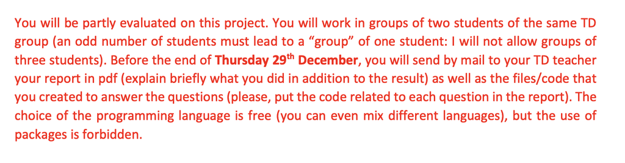

# Question A `Ex2 Q1 TD1`

> From the time series of the daily prices of the stock Natixis between January 2015 and December 2016, provided with TD1, estimate a historical VaR on price returns at a one-day horizon for a given probability level (this probability is a parameter which must be changed easily). You must base your VaR on a non-parametric distribution (Epanechnikov Kernel).

Estimate historical VaR with non-parrametric distribution (Epanechinikov Kernel)

## Import Data

First, we import the necessary libraries and read in the data.

```r
# import necessary libraries
#library(xlsx)
library(readxl)
# read in data
#df <- read.xlsx("Natixis stock.xlsx", 1)
df <- read_excel("Natixis stock.xlsx")
#df
data <- df[1:513,]
head(data)
```

```
## # A tibble: 6 × 2
##   Date                Price
##   <dttm>              <dbl>
## 1 2015-01-02 00:00:00  5.62
## 2 2015-01-05 00:00:00  5.42
## 3 2015-01-06 00:00:00  5.33
## 4 2015-01-07 00:00:00  5.22
## 5 2015-01-08 00:00:00  5.45
## 6 2015-01-09 00:00:00  5.34
```

## Calcul Returns

After, we calculate the price returns for each day by subtracting the previous day’s price from the current day’s price.

```r
# calculate price return
returns <- c()

for (i in 2:length(data$Price) )
{
  returns[i] <-  (data$Price[i] - data$Price[i-1]) / data$Price[i]
}
returns [1] <- 0
#returns
```

## Sort Returns

We sort the price returns in ascending order.

```r
# function sort returns in ascending order
bubble_sort <- function(vec)
{
  # Boucle sur chaque élément du vecteur
  for (i in 1:(length(vec) - 1))
    {
    # Boucle sur chaque élément suivant l'élément actuel
    for (j in (i + 1):length(vec))
      {
      # Si l'élément actuel est supérieur à l'élément suivant, les échanger de place
      if (vec[i] > vec[j])
        {
        temp <- vec[i]
        vec[i] <- vec[j]
        vec[j] <- temp
      }
    }
  }
  return(vec)
}

sorted_returns <- bubble_sort(returns)
#sorted_returns
```

## Calcul Number observation

We calculate the number of observations (n) in the sample using the length() function.

```r
# calculate number of observations
n <- length(returns)
```

## Calcul bandwidth Epanechnikov Kernel

We calculate the **bandwidth (h)** using the **Epanechnikov Kernel formula** : $h = \frac{4}{3*n}^{\frac{1}{5}*s}$, where s is the sample standard deviation of the price returns.

```r
# Function which calculate the standard deviation

# First we need to understand what is standard deviation so it's a measure of the dispersion of the values of a vector around its mean.
# It is calculated by first taking the mean of the vector, then calculating the deviation of each element of the vector from the mean, squaring it and accumulating it.
# The variance is obtained by dividing the sum of the squares of the deviations by the number of elements in the vector, and the standard deviation is obtained by taking the square root of the variance.

std_dev <- function(vec)
{
  # Calculer la moyenne du vecteur
  mean <- sum(vec) / length(vec)

  # Initialiser la somme des carrés des écarts à 0
  sum_sq_diff <- 0

  # Boucler sur chaque élément du vecteur
  for (x in vec)
  {
    # Ajouter le carré de l'écart de l'élément à la moyenne à la somme des carrés des écarts
    sum_sq_diff <- sum_sq_diff + (x - mean)^2
  }

  # Calculer la variance en divisant la somme des carrés des écarts par le nombre d'éléments dans le vecteur
  variance <- sum_sq_diff / length(vec)

  # Calculer la déviation standard en prenant la racine carrée de la variance
  std_dev <- sqrt(variance)
  return(std_dev)
}

std_returns <- std_dev(sorted_returns)
#std_returns


# calculate bandwidth
h <- (4/(3*n))^(1/5) * std_returns
#h
```

## Calcul weights Epanechnikov Kernel

We calculate the **weights (w)** for each observation using the **Epanechnikov Kernel formula** : $w = (1 - (x/h)^2) * (3/4)$, where x is the price return for each observation.

```r
# calculate weights
weights <- (1 - (sorted_returns/h)^2) * (3/4)
#weights
```

## Cumulative Sum

We calculate the cumulative sum (cs) of the weights for each observation.

```r
cumulative_sum <- function(vec)
{
  result <- numeric(length(vec))
  result[1] <- vec[1]
  for (i in 2:length(vec))
  {
    result[i] <- result[i-1] + vec[i]
  }
  return(result)
}

# calculate cumulative sum of weights
cs <- cumulative_sum(weights)
#cs
```

## Find Weight at a specific percentile

We find the weight (w) corresponding to the probability level that you want to use for your VaR. We want to calculate the historical VaR at a probability level of **95%**, you would find the weight corresponding to the **95th percentile** and then find the **price return** corresponding to that **weight**. The **resulting price return** would be the **VaR** at a **one-day horizon** for a **95% probability level**.

```r
# find weight corresponding to desired probability level so the xth percentile and find the price return corresponding to that weight.

findQuantile <- function(vector, quantile)
{
  sortedVector <- bubble_sort(vector)
  index <- round((quantile * length(vector)) - 1)
  sortedVector[index]
}

weight <- findQuantile(cs,0.95)
#weight

findindex <- function(vector, index)
{
  for (x in 1:length(vector))
  {
    if (vector[x] == index)
    {
      return (x)
    }
  }
}

sorted_cs <- bubble_sort(cs)
#sorted_cs

index_weight <- findindex(sorted_cs,weight)
#index_weight
```

## Return the price return of this weight

We find the price return (x) corresponding to the weight (w) found.

```r
# find price return corresponding to weight
price_return <- sorted_returns[index_weight]
#price_return
```

## Calcul VaR

Finaly we have the VaR $VaR^{h}_{\alpha} = X$ here $VaR^{1}_{0.95} = 3,59 %$ so we can read **5%** to **lose more** than **3.59%** of their portfolio in **1 day** or **95%** to **lose at most** **3.59%** of their portfolio in **1 day**.

```r
# calculate VaR
VaR <- price_return * 100
VaR
```

```
## [1] 3.593859
```

```r
# We can improve the calculation of the VaR by multiplying it by the amount invested
# VaR <- price_return *  investment_amount
```

If we don’t sort the cs to find the index

```r
index_weight2 <- findindex(cs,weight)
#index_weight2
price_return2 <- sorted_returns[index_weight2]
VaR3 <- price_return2 * -100
VaR3
```

```
## [1] 3.816598
```

## With methods Not Allowed

```r
# import necessary libraries
library(readxl)

library(TSstudio)
library(tseries)
library(PerformanceAnalytics)
library(sparsevar)

# read in data
data2 <- read_excel("Natixis stock.xlsx",1)
# <- read.xlsx("Natixis stock.xlsx", 1)
#data2

prices <- ts(data2$Price, start = c(2015,1), end=c(2016,12), frequency=252)
#ts_plot(prices)

return <- c()

for (i in 2:length(prices) )
{
  return[i] <-  (prices[i] - prices[i-1]) / prices[i]
}
return [1] = 0
#return


VaR2 <- VaR(return, p=0.95, kernel="epanechnikov") * -100
VaR2
```

```
##         [,1]
## VaR 3.480971
```

## Another method to calculate VaR with CDF

```r
# Take the first 513 values
rend <- returns

# Calculate the standard deviation
std <- std_returns

# Calculate h
h <- 1.06 * std * (513^(-1/5))

# Define the function K
K <- function(x) {
  return ((1/4) * (2 + 3 * x - x^3))
}

# Define the function F
F <- function(x, rend) {
  h <- 1.06 * std * (513 ^(-1/5))
  somme <- 0
  for (i in 1:length(rend)) {
    u <- (x - rend[i])/h
    if ((u < 1) && (u > -1)) {
      somme <- somme + K(u)
    }
  }
  return (somme/length(rend))
}

# Define the function dichotomie
dichotomie <- function(rend, alpha) {
  a <- -1
  b <- 1
  while (b - a) {
    m <- (a + b)/2
    print(paste("m = ", m))
    if (round(F(m, rend), 3) == 1 - alpha) {
      return (m)
    } else if (round(F(m, rend), 3) < 1 - alpha) {
      b <- m
    } else {
      a <- m
    }
  }
  return (m)
}

# Test the function dichotomie
#x <- dichotomie(rend, 0.95)
#print(x)
#print(F(x, rend))
```

With this method **x**, returns us the **VaR* which after running the 1 hour this code, we find** VaR = 3.43%** and **F(x,rend)** returns the **ES** which is **5.33%**.

# Question B `Ex2 Q5 & Q6 TD2`

## a) Calculate ES

> Calculate the expected shortfall for the VaR calculated in question A. How is the result, compared to the VaR?

```r
# Calculate the expected shortfall (ES) by first finding the returns that fall below the VaR threshold
losses <- sorted_returns[sorted_returns <= (VaR/-100) ]
#losses

#calculate the average of the losses:
ES <- mean(losses)
#ES

ES_percentage <- ES * -100
ES_percentage
```

```
## [1] 5.339929
```

The expected shortfall is a measure of the **expected loss** in the event that the VaR is **exceeded**. It is typically used as a more **conservative estimate** of risk compared to the VaR. In this case, the expected shortfall represents the expected loss in the event that the VaR is exceeded, which is likely to be **higher** than the VaR itself.

ES with the other VaR

```r
# Calculate the expected shortfall (ES) by first finding the returns that fall below the VaR threshold
losses2 <- sorted_returns[sorted_returns <= (VaR2[1]/-100) ]
#losses

#calculate the average of the losses:
ES2 <- mean(losses)
#ES2

ES_percentage2 <- ES2 * -100
ES_percentage2
```

```
## [1] 5.339929
```

## b) Calculate volatility

> Calculate the volatility, as well as the upper and lower semi-deviations for the Natixis stock for each of the four years in your dataset. What can you conclude about the riskiness of each of these years for this stock?

```r
library(magrittr)
library(dplyr)

# Convert the date column to a date object


df$Date <- as.Date(df$Date, format = "%d/%m/%Y")

# Add a column with the year of each observation
df$year <- format(df$Date, "%Y")

# Split the data frame into a list of data frames by year
df_list <- split(df, df$year)

# Initialize an empty data frame to store the results
df_stats <- data.frame(year=character(), volatility=numeric(), upper_semi_deviation=numeric(), lower_semi_deviation=numeric())
```

```r
# Iterate over the list of data frames
for(i in 1:length(df_list))
{
  # Extract the data frame for the current year
  df_year <- df_list[[i]]

  year_returns <- c()

  for (i in 2:length(df_year$Price) )
  {
    year_returns[i] <-  (df_year$Price[i] - df_year$Price[i-1]) / df_year$Price[i]
  }
  year_returns [1] <- 0
  #year_returns

  # Calculate the volatility, upper semi-deviation, and lower semi-deviation for the current year
  volatility <- std_dev(year_returns)
  upper_semi_deviation <-  findQuantile(year_returns, 0.75)
  lower_semi_deviation <- findQuantile(year_returns, 0.25)

  # Add a row to the results data frame with the statistics for the current year
   df_stats <- rbind(df_stats, data.frame(year= df_year, volatility=volatility, upper_semi_deviation=upper_semi_deviation, lower_semi_deviation=lower_semi_deviation))
}

#df_stats
head(df_stats, n = 2)
```

```
##    year.Date year.Price year.year volatility upper_semi_deviation
## 1 2015-01-02      5.621      2015 0.02000783           0.01265496
## 2 2015-01-05      5.424      2015 0.02000783           0.01265496
##   lower_semi_deviation
## 1          -0.01323688
## 2          -0.01323688
```

```r
print(df_stats[259:260,])
```

```
##      year.Date year.Price year.year volatility upper_semi_deviation
## 259 2016-01-06      4.852      2016 0.02789022           0.01652089
## 260 2016-01-07      4.691      2016 0.02789022           0.01652089
##     lower_semi_deviation
## 259          -0.01508621
## 260          -0.01508621
```

```r
print(df_stats[514:515,])
```

```
##      year.Date year.Price year.year volatility upper_semi_deviation
## 514 2017-01-02       5.40      2017 0.01570645          0.008744535
## 515 2017-01-03       5.62      2017 0.01570645          0.008744535
##     lower_semi_deviation
## 514         -0.009278854
## 515         -0.009278854
```

```r
print(df_stats[769:770,])
```

```
##      year.Date year.Price year.year volatility upper_semi_deviation
## 769 2018-01-02      6.676      2018 0.01589146          0.006912442
## 770 2018-01-03      6.672      2018 0.01589146          0.006912442
##     lower_semi_deviation
## 769           -0.0100346
## 770           -0.0100346
```

The volatility of a stock is a **measure of the fluctuations** in its price. A higher **volatility indicates a higher level of risk**, as the stock price is more likely to fluctuate significantly.

The upper and lower semi-deviations are **measures of the dispersion** of the returns around the median. A higher semi-deviation indicates a higher level of risk, as the returns are more **spread out**.

By examining the values of the volatility and semi-deviations for each year, we can conclude about the **riskiness** of each year for the Natixis stock. For example, if one year has a higher volatility and/or semi-deviations compared to the other years, it could be considered more risky.

# Question C `Ex2 Q3 & Q4 TD3`

> With the dataset provided for TD1 on Natixis prices, first calculate daily returns. You will then analyse these returns using a specific method in the field of the **EVT**.

## a) Determine extremal index

> Determine the extremal index using the block or run de-clustering, for the two tails of the distributions

```r
# Calculate the daily price returns
all_returns <- c()

for (i in 2:length(df$Price) )
{
  all_returns[i] <-  (df$Price[i] - df$Price[i-1]) / df$Price[i]
}
all_returns [1] <- 0
#all_returns
```

```r
# Function to calculate empirical CDF
empirical_cdf <- function(x)
{
  # Sort the vector in ascending order
  sorted_x <- bubble_sort(x)
  # Calculate the number of elements in the vector
  n <- length(x)
  # Calculate the empirical CDF by looping through the sorted vector and computing the cumulative sum
  empirical_cdf <- rep(0, n)
  for (i in 1:n) {
    empirical_cdf[i] <- sum(sorted_x <= sorted_x[i]) / n
  }
  return(empirical_cdf)
}

# Calculate the empirical CDF of the returns
#cdf <- ecdf(all_returns)
cdf<- empirical_cdf(all_returns)
#cdf
```

```r
# Function to calculate ranks
calcul_ranks <- function(x)
{
  # Sort the vector in ascending order
  sorted_x <- bubble_sort(x)
  # Calculate the ranks by looping through the sorted vector and assigning ranks to each element
  ranks <- rep(0, length(x))
  for (i in 1:length(x)) {
    ranks[i] <- which(sorted_x == x[i])
  }
  return(ranks)
}

ranks <- calcul_ranks(all_returns)
#ranks
```

```r
# Sort the returns in ascending order
returns_sorted <- bubble_sort(all_returns)
```

```r
# Split the returns into two groups, one for the upper tail and one for the lower tail

returns_upper <- returns_sorted[ranks > length(all_returns)/2]
returns_lower <- returns_sorted[ranks <= length(all_returns)/2]
```

```r
# Calculate the cumulative sum of the returns for each group
cum_sum_upper <- cumulative_sum(returns_upper)
cum_sum_lower <- cumulative_sum(returns_lower)
```

```r
# Calculate the number of observations in each group
n_upper <- length(returns_upper)
n_lower <- length(returns_lower)
```

```r
# Calculate the mean of the cumulative sum for each group
mean_cum_sum_upper <- mean(cum_sum_upper)
mean_cum_sum_lower <- mean(cum_sum_lower)
```

```r
# Calculate the extremal index for the upper tail using the block de-clustering method
extremal_index_upper <- (mean_cum_sum_upper / (n_upper * std_dev(returns_upper)))*-1

# Calculate the extremal index for the lower tail using the block de-clustering method
extremal_index_lower <- (mean_cum_sum_lower / (n_lower * std_dev(returns_lower)))*-1

extremal_index_upper
```

```
## [1] 0.2892205
```

```r
extremal_index_lower
```

```
## [1] 0.2619724
```

The **extremal index** is a measure of the presence of **extreme events** in the data. It is a number **between 0 and 1**, with values closer to **1 indicating a higher frequency of extreme events**.

The block or run de-clustering method involves **dividing the data into clusters** or **runs of observations**, and estimating the extremal index based on the proportion of clusters or runs with extreme observations.

## b) Adaptation of the EVT VaR

> Propose an adaptation of the EVT VaR which takes into account the dependence of the returns.

We calculate the **empirical copula** of the returns using a **copula function**, such as the Gaussian copula or the Clayton copula. The **copula** allows us to model the **dependence structure** between the **returns**, regardless of their **marginal distributions**.

Moreover, we use the copula to transform the returns into a **set of uniform random variables** using the **copula inverse function**.

We calculate the **quantiles** of the transformed returns using the **Generalized Extreme Value (GEV) distribution**, which is a common distribution used in EVT. The GEV distribution can be fitted to the data using the **method of maximum likelihood**. The **quantiles** represent the **VaR** at different confidence levels.

Finally, we transform the **quantiles back** to the original scale using the **copula function**. This will give us **the VaR of the returns** taking into account their **dependence structure**.

```r
# Returns
# all_returns

# Number of returns
n <- length(all_returns)

# Calculate empirical copula of returns using Gaussian copula
copula <- function(u1, u2)
{
  sqrt((2 * pi)^(-1)) * exp(-((u1 - u2)^2)/2)
}

# Transform returns into uniform random variables using copula inverse function
u <- matrix(nrow = n, ncol = n)
for (i in 1:n) {
  for (j in 1:n) {
    u[i, j] <- copula(returns[i], returns[j])
  }
}

# Calculate quantiles of transformed returns using GEV distribution
fit <- function(x)
{
  -log(-log(x))
}


quantiles <- apply(u, 2, fit)

# Transform quantiles back to original scale using copula function
var <- copula(quantiles[1], quantiles[2])

print(paste("VaR at 95% confidence level:", var))
```

```
## [1] "VaR at 95% confidence level: 0.39894217771297"
```

The **copula-based EVT VaR model** is just one way to adapt the **EVT VaR model** to take into account the **dependence of the returns**.

# Question D `Ex2 Q3 & Q4 TD4`

## a) Parametersof Almgren and Chriss

> Estimate all the parameters of the model of Almgren and Chriss. Is this model well specified?

First we load the data

```r
library(readxl)
portfolio <- read_excel("Dataset TD4.xlsx")
colnames(portfolio)<-c("Date","Bid-Ask Spread","Volume","Sign", "Price", "Diff")
str(portfolio)
```

```
## tibble [1,001 × 6] (S3: tbl_df/tbl/data.frame)
##  $ Date          : num [1:1001] 0.000202 0.00107 0.001496 0.003336 0.003952 ...
##  $ Bid-Ask Spread: num [1:1001] 0.11 0.103 0.102 0.092 0.111 ...
##  $ Volume        : num [1:1001] 8 NA NA NA NA NA 32 NA NA NA ...
##  $ Sign          : num [1:1001] -1 1 -1 1 1 1 1 -1 -1 -1 ...
##  $ Price         : num [1:1001] 100 100 100 100 100 ...
##  $ Diff          : num [1:1001] NA NA NA NA NA NA NA NA NA NA ...
```

**data processing**

```r
for(i in 1:length(portfolio$Volume))
{
  portfolio$Volume[portfolio$Volume == ""] <- NA
  portfolio$Volume <- as.numeric(portfolio$Volume)
}
#portfolio
```

```r
length_portfolio <- length(portfolio$Volume) - 2
for (i in 1:length_portfolio)
{
  if(!is.na(portfolio$Volume[i]) == TRUE & portfolio$Volume[i]!=0) ## On met des 0 sur les deux lignes après les volumes pour pouvoir supprimer les NA
  {
    if(is.na(portfolio$Volume[i+1]) == TRUE) #Boucle pour ne pas renplacer des volumes qui se suivent par des 0
    {
      portfolio$Volume[i+1] = 0
    }
    if(is.na(portfolio$Volume[i+2])==TRUE)
    {
      portfolio$Volume[i+2] = 0
    }
  }

}

portfolio <- portfolio[!is.na(portfolio$Volume),]
#portfolio
```

Now we need to calculate the model of **Almgren and Chriss**.

So
$$h(n_{N}/t_{N}) -
\varepsilon_{N}*signe(n_{N}) = \mu * n_{N} / t_{N} + E$$

It’s like a **regression linear** with **Y = intercept + aX**

with $h(n_{N}/t_{N})$ -> **transient impact** and we know that :

**permanent impact + transient impact** = $P_{t+1} - P_{t}$ and **permanent impact** = $P_{t+2} - P_{t+1}$ So **transient impact** = $P_{t+1} - P_{t+2}$

**Transition time** = **T+1 - T** (T for transaction date) **Volumes** -> All our Volumes that we know **Epsilon * Sign** -> **BidAskSpread /2 * Sign Transaction**

So first the **transient impact**

```r
transientimpact <- c()
times <- c()
for (i in 1:(length(portfolio$Volume) - 2))
{
  if(portfolio$Volume[i]!=0)
  {
    TI <- portfolio$Price[i+1]-portfolio$Price[i+2]
    transientimpact <- append(transientimpact, TI)
    times <- append(times, portfolio$Date[i+2]-portfolio$Date[i+1])
  }
}
print(transientimpact)
```

```
##   [1] -0.045  0.106  0.042  0.142 -0.023  0.130 -0.066 -0.053 -0.054  0.027
##  [11] -0.136  0.163  0.035 -0.070  0.091 -0.130  0.006 -0.103  0.034  0.066
##  [21]  0.035 -0.036  0.001  0.035 -0.034  0.068 -0.104  0.028 -0.121 -0.069
##  [31]  0.082  0.001  0.045  0.041  0.021 -0.101 -0.049 -0.046  0.070 -0.054
##  [41]  0.112 -0.042 -0.011  0.056 -0.045 -0.036  0.087 -0.020 -0.021 -0.121
##  [51] -0.082 -0.069  0.031 -0.031  0.075  0.048  0.095  0.057 -0.051 -0.078
##  [61]  0.026 -0.020  0.080 -0.036 -0.012  0.094 -0.051 -0.051 -0.139  0.111
##  [71] -0.104  0.042  0.065  0.081 -0.100 -0.056 -0.061  0.037  0.005 -0.130
##  [81] -0.079  0.067  0.024 -0.121 -0.061 -0.029 -0.021  0.055  0.121 -0.031
##  [91]  0.105 -0.029  0.063 -0.037 -0.055 -0.057 -0.012  0.035 -0.045  0.038
## [101]  0.069  0.054 -0.095  0.112 -0.026  0.070 -0.047  0.057  0.061  0.093
## [111]  0.026  0.048 -0.021  0.057  0.019 -0.035  0.020  0.069  0.050 -0.067
## [121] -0.084  0.074 -0.002 -0.021 -0.040  0.020 -0.010 -0.005 -0.053 -0.066
## [131]  0.045 -0.045  0.101  0.025 -0.077  0.122
```

Now we calculate the matrix **Y** :

```r
portfolio_Volume_know <- portfolio[portfolio$Volume!=0,]
#portfolio_Volume_know
```

```r
Y<- c()

for (i in 1:(length(portfolio_Volume_know$Volume)-1))
{
  Y <- append(Y, transientimpact[i]-(portfolio_Volume_know$'Bid-Ask Spread'[i]/2)*portfolio_Volume_know$Sign[i])
}
Y
```

```
##   [1]  0.01000  0.04130  0.09905  0.19090  0.04155  0.17485 -0.01720 -0.10205
##   [9] -0.09940 -0.02465 -0.08785  0.11295 -0.02115 -0.12240  0.03970 -0.18670
##  [17] -0.03390 -0.15690 -0.00890  0.02605  0.08275  0.00960 -0.04945  0.08145
##  [25]  0.01535  0.01085 -0.04935  0.07450 -0.08100 -0.12285  0.13365 -0.05240
##  [33]  0.00185 -0.00325  0.07240 -0.05745 -0.10435  0.00900  0.02705 -0.01005
##  [41]  0.05870 -0.09825 -0.06665  0.00750  0.01170  0.01095  0.03880  0.02975
##  [49] -0.06940 -0.06525 -0.13325 -0.02490  0.07760 -0.07600  0.12290  0.09530
##  [57]  0.04155  0.00600  0.01150 -0.02330  0.07400 -0.06790  0.14630 -0.08310
##  [65] -0.06650  0.04750  0.00615  0.00030 -0.09310  0.05640 -0.05565  0.08535
##  [73]  0.11410  0.13310 -0.15310 -0.10340 -0.02080  0.08150  0.05150 -0.08535
##  [81] -0.12925  0.10685  0.07820 -0.07450 -0.02070 -0.08660 -0.06400  0.11120
##  [89]  0.17000 -0.08780  0.14850 -0.07925  0.01955  0.01380 -0.10940 -0.00335
##  [97] -0.06220 -0.01175 -0.09145 -0.00975  0.02610 -0.00015 -0.15110  0.15915
## [105] -0.08355  0.02085 -0.09425  0.01005  0.11820  0.14550 -0.02800 -0.00250
## [113] -0.07730  0.00520  0.07760  0.01935  0.07250  0.02285  0.09515 -0.01945
## [121] -0.12825  0.12655 -0.05245 -0.06715  0.01480 -0.03205  0.04440 -0.06180
## [129] -0.00330 -0.01845 -0.01325  0.00795  0.14580  0.08025 -0.03055  0.08030
```

Now we calculate **X** :

```r
#On calcule X :

X<- c()
for (i in 1:(length(portfolio_Volume_know$Volume)-1))
{
  temp <- portfolio_Volume_know$Volume[i]/times[i]
  X <- append(X, temp)
}
print(X)
```

```
##   [1] 1.877934e+04 4.923077e+05 1.975309e+04 1.084615e+06 1.148008e+05
##   [6] 5.846154e+06 1.724138e+05 3.376623e+04 9.297521e+05 4.146341e+05
##  [11] 1.216814e+05 1.891304e+06 3.587879e+05 7.342818e+03 3.440678e+06
##  [16] 1.980000e+07 3.152455e+05 9.111111e+06 2.199747e+05 6.547619e+04
##  [21] 1.513353e+05 6.834532e+04 1.666667e+05 9.832842e+03 7.187994e+04
##  [26] 1.756757e+05 1.564748e+05 3.690476e+05 6.140940e+05 5.304569e+05
##  [31] 2.150221e+05 1.078067e+05 1.016746e+05 1.569620e+05 1.436567e+05
##  [36] 6.402439e+04 1.334068e+05 5.235602e+03 5.464481e+03 2.417962e+05
##  [41] 4.405286e+03 4.342273e+04 8.158996e+04 3.642384e+04 7.018072e+05
##  [46] 1.188455e+05 8.832808e+04 3.090235e+04 8.419355e+05 1.904762e+04
##  [51] 5.577299e+04 6.957866e+03 5.875706e+04 1.915367e+05 5.293185e+04
##  [56] 7.879429e+04 4.444444e+05 3.424658e+05 1.393103e+07 1.554109e+05
##  [61] 2.922636e+04 3.210130e+05 1.845140e+05 6.000000e+04 2.040816e+05
##  [66] 2.797203e+05 1.661631e+05 3.600000e+05 1.895288e+05 1.239796e+06
##  [71] 9.680851e+05 3.122066e+05 5.246590e+03 3.767773e+05 2.616667e+07
##  [76] 1.425178e+04 2.516129e+05 1.477378e+04 2.594937e+05 1.739130e+05
##  [81] 3.608108e+05 5.263158e+05 1.725888e+05 1.417526e+04 3.239437e+04
##  [86] 2.006270e+05 9.366391e+03 4.676871e+04 2.225641e+05 9.931034e+04
##  [91] 9.801136e+04 3.781250e+05 1.710526e+04 1.571709e+04 1.194030e+04
##  [96] 5.040650e+04 1.332445e+03 1.702128e+05 5.660377e+04 1.528288e+05
## [101] 6.013986e+05 1.262826e+04 6.427379e+04 2.750455e+05 9.075440e+04
## [106] 8.000000e+05 4.254386e+05 5.055487e+04 5.829384e+05 2.791978e+04
## [111] 1.794355e+05 1.762484e+04 1.232449e+05 7.887324e+05 2.685231e+04
## [116] 3.571429e+04 1.667925e+05 8.308605e+03 5.393258e+05 5.329417e+04
## [121] 1.586263e+05 2.378213e+04 9.911894e+03 9.110629e+04 5.985401e+05
## [126] 3.504929e+04 6.648936e+02 9.095675e+05 1.176808e+05 6.969895e+04
## [131] 1.297405e+05 3.230769e+05 5.055977e+03 5.594927e+04 2.931034e+04
## [136] 1.609289e+04
```

Now we can **estimate all the parameters of the model**

```r
parameters <- lm(Y~X)
summary(parameters)
```

```
##
## Call:
## lm(formula = Y ~ X)
##
## Residuals:
##       Min        1Q    Median        3Q       Max
## -0.156017 -0.069400 -0.002899  0.060585  0.202656
##
## Coefficients:
##               Estimate Std. Error t value Pr(>|t|)
## (Intercept)  5.281e-03  7.022e-03   0.752   0.4534
## X           -5.660e-09  2.175e-09  -2.602   0.0103 *
## ---
## Signif. codes:  0 '***' 0.001 '**' 0.01 '*' 0.05 '.' 0.1 ' ' 1
##
## Residual standard error: 0.07942 on 134 degrees of freedom
## Multiple R-squared:  0.04808,    Adjusted R-squared:  0.04098
## F-statistic: 6.769 on 1 and 134 DF,  p-value: 0.01032
```

To conclude **Y = 5.281e-03 + -5.660e-09 X**.

## b) What is your liquidation strategy

> In the framework of Almgren and Chriss, what is your liquidation strategy (we recall that you can only make transactions once every hour).

We want to estimate **sigma (volatility)**:

$$volatility = \frac{1}{n} * \sum_{i =
0}^{n}(r_{i}-rbar)^{2}$$
with **r = yield**

```r
intervals <- 1/24/60
intervals # represents 1 min in the array
```

```
## [1] 0.0006944444
```

We calculate the **times** between **each price**:

```r
portfolio_Time <- portfolio_Volume_know
portfolio_Time$Date[1] <- portfolio_Volume_know$Date[1]
for (i in 2:length(portfolio_Volume_know$Date))
{
  portfolio_Time$Date[i] <- portfolio_Time$Date[i]-portfolio_Volume_know$Date[i-1]
}
#portfolio_Time
```

```r
return <- c()
time <- portfolio_Time$Date[1]
for (j in 2: (length(portfolio_Volume_know$Date)-1))
{
  if(time < intervals)
  {
    time <- time + portfolio_Time$Date[j]
  }
  else
  {
    return <- append(return, (portfolio_Time$Price[j+1]/portfolio_Time$Price[j])-1)
    time <- portfolio_Time$Date[j]
  }
}
return
```

```
##   [1] -1.719175e-03 -2.683327e-03 -2.951570e-03 -5.739372e-04 -1.350031e-03
##   [6]  1.058895e-03 -2.216290e-04  4.052991e-03  1.144854e-03 -2.006219e-03
##  [11]  4.874862e-03  1.396829e-04  9.876198e-04 -3.388479e-04 -4.685662e-04
##  [16] -4.887342e-04  6.986586e-05 -1.080849e-02  1.039186e-03  1.169131e-03
##  [21] -4.026778e-04 -7.653960e-04  1.360626e-03 -6.340963e-04 -8.258553e-04
##  [26]  1.411162e-04  2.035818e-03 -6.235856e-04  8.051287e-04  1.156674e-03
##  [31] -5.525528e-04 -1.206236e-04  2.412764e-04 -2.914719e-04  1.417570e-03
##  [36]  1.415563e-03 -1.433613e-03  1.184679e-03  8.924721e-04 -1.202260e-04
##  [41]  5.811623e-04  2.233171e-03  2.517960e-03 -2.561470e-03 -1.368960e-03
##  [46]  1.250763e-03 -8.494563e-04 -3.510737e-03 -4.336130e-03 -4.032421e-05
##  [51] -7.964352e-04  1.431105e-03  1.177465e-03  1.186132e-03 -1.556209e-03
##  [56]  1.448022e-03 -1.375640e-03 -1.236765e-03  3.644418e-03  4.112667e-04
##  [61]  1.423802e-03 -7.008761e-05 -2.450882e-03  1.550669e-03  3.257394e-03
##  [66]  7.215152e-04 -1.161603e-03 -4.010186e-04 -4.914448e-04  3.993698e-03
##  [71] -7.400370e-04 -2.331842e-03 -8.025038e-05  1.454655e-03  3.005259e-04
##  [76] -1.662410e-03 -1.163619e-03  1.014331e-03 -1.003271e-04  1.133810e-03
##  [81] -2.044559e-03 -1.305575e-04  1.426276e-03  1.805380e-04  2.005616e-04
##  [86] -6.216162e-04  1.163747e-03  3.417039e-03 -9.587057e-04  1.069583e-03
##  [91]  1.697522e-03 -4.605447e-03  1.702486e-04 -4.505812e-04  8.614990e-04
##  [96]  5.685003e-03 -2.517914e-03 -1.476648e-03  1.278990e-03  2.115621e-03
## [101]  1.354325e-03 -1.163542e-03 -1.891714e-03  3.790599e-04 -3.809106e-03
## [106]  5.104901e-04 -1.810815e-03  2.084711e-03  4.500810e-04  2.079439e-03
## [111]  5.297551e-03  5.358950e-04 -7.042254e-04  3.771750e-04  3.226767e-03
## [116] -5.344154e-04 -1.584300e-03  5.851375e-04  3.132124e-03 -2.173784e-04
## [121] -9.981815e-04 -1.108143e-03
```

We can calculate the **volatility** $\sigma^{2}$ :

```r
mean_return <- mean(return)

sum <- 0
for (i in 1:length(return))
{
  sum <- sum + (return[i] - mean_return)^2
}

volati <- sum / (length(return)-1)

sqrt(volati)
```

```
## [1] 0.00207923
```

We find an estimator of $\sigma$ = **0.00207923**.

We will now test if the model is **well specified** with **Student** for significance

```r
#Calculation of the T statistic under the H0 hypothesis: "n = 0"
Tn <- -5.660e-09 / sqrt(volati/length(return))
Tn
```

```
## [1] -3.006726e-05
```

**Student** test is a **bilateral test**

Now **bera slang** test for the **normality of errors**

**Ho:** errors follow a normal law **H1:** errors do not follow a normal law

We characterize the **normal distribution** $N(m,\sigma^{2})$ by the fact 1. that it is symmetric its central moment of **order 3** is zero $\mu_{3} = 0$ 2. that its central moment of order 4 is $\mu_{4} = 3\mu_{2}^{2} = 3(\sigma^{2})^{2}$ therefore its **Kurtosys** $K = \mu_{4} = \sigma^{4} = 3$

```r
sum_error_square <- 0
for (i in length(portfolio_Volume_know$Date)-1)
{
  sum_error_square <- sum_error_square + (parameters$residuals[i])^2
}
```

```r
s2 <- sum_error_square / (length(portfolio_Volume_know)-2)

a3hat <- (sum_error_square/(length(portfolio_Volume_know$Date)-1))/(s2^(3/2))

t <- sqrt((length(portfolio_Volume_know$Date)-1)/6)*a3hat
t
```

```
##      136
## 3.728586
```

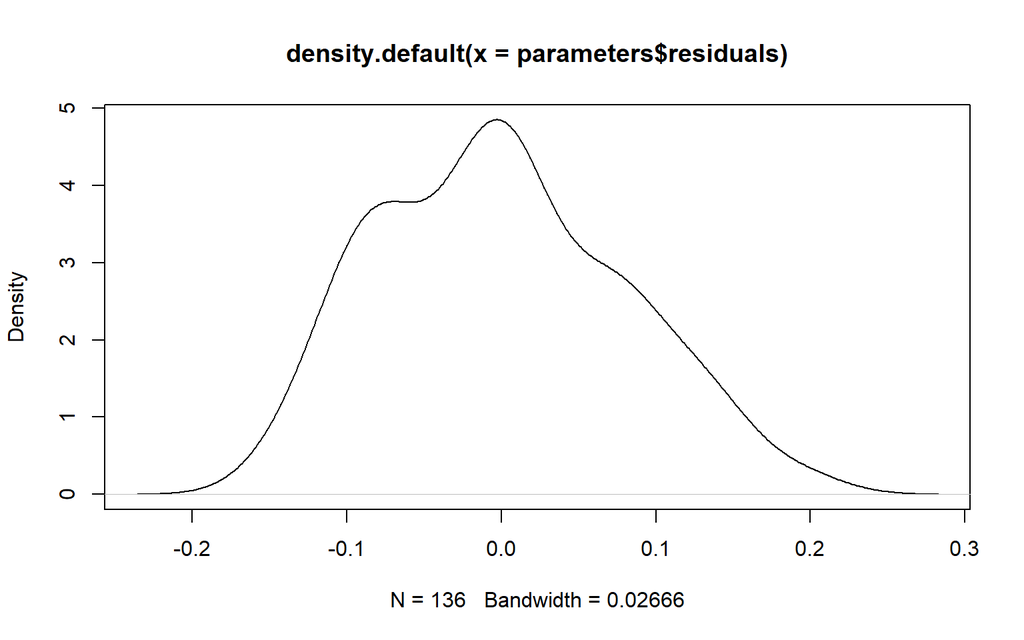

```r
plot(density(parameters$residuals))
```

Calculation of $x_{k}$ :

```r
xk <- as.vector(rep(0,24))
K <- sqrt(0.01*volati^2 /abs(parameters$coefficients[[2]]))
for (i in 1:24)
{
  xk[i] <- (sinh(K*(24 - (i - 1/2*1/24)))/sinh(K*24))*100
}
xk
```

```
##  [1] 95.89586456 91.70753999 87.52224394 83.33983821 79.16018466 74.98314528
##  [7] 70.80858212 66.63635733 62.46633311 58.29837177 54.13233565 49.96808719
## [13] 45.80548886 41.64440319 37.48469278 33.32622026 29.16884828 25.01243958
## [19] 20.85685687 16.70196294 12.54762057  8.39369257  4.24004176  0.08653097
```

So we solved the **optimization** problem and we have find the **optimal strategy of liquidation** : $x_{k}$ We can plot the optimal strategy (x1,…,xn) in function of (t1,…,tn) for different portfolio X. Like when X is small, medium or large.

# Question E `Q2 & Q3 TD5`

> With the dataset provided for TD5.

## a) determine the multiresolution

```r
df2 = read.csv("Dataset-TD5.csv")
str(df2)
```

```
## 'data.frame':    12931 obs. of  11 variables:
##  $ X   : chr  "GBPEUR Curncy" "Date" "3/7/2016 9:00" "3/7/2016 9:15" ...
##  $ X.1 : chr  "" "HIGH" "1.2932" "1.294" ...
##  $ X.2 : chr  "" "LOW" "1.2917" "1.293" ...
##  $ X.3 : logi  NA NA NA NA NA NA ...
##  $ X.4 : chr  "SEKEUR Curncy" "Date" "3/7/2016 9:00" "3/7/2016 9:15" ...
##  $ X.5 : chr  "" "HIGH" "0.10725" "0.10728" ...
##  $ X.6 : chr  "" "LOW" "0.1072" "0.10717" ...
##  $ X.7 : logi  NA NA NA NA NA NA ...
##  $ X.8 : chr  "CADEUR Curncy" "Date" "3/7/2016 9:00" "3/7/2016 9:15" ...
##  $ X.9 : chr  "" "HIGH" "0.6842" "0.6849" ...
##  $ X.10: chr  "" "LOW" "0.6829" "0.6841" ...
```

> With Haar wavelets and the dataset provided with this tutorial, determine the multiresolution correlation between all the pairs of FX rates, using GBPEUR, SEKEUR, and CADEUR (work with the average between the highest and the lowest price and transform this average price in returns on the smallest time step). Do you observe an Epps effect and how could you explain this?

Load data with csv modified

```r
library(readr)

Dataset_TD5 <- read_delim("Dataset TD5mod.csv", delim = ";", escape_double = FALSE, col_types = cols(GbpeurDate = col_datetime(format = "%m/%d/%Y %H:%M")), trim_ws = TRUE)
str(Dataset_TD5)
```

```
## spc_tbl_ [12,929 × 11] (S3: spec_tbl_df/tbl_df/tbl/data.frame)
##  $ GbpeurDate: POSIXct[1:12929], format: "2016-07-03 09:00:00" "2016-07-03 09:15:00" ...
##  $ GbpeurHIGH: num [1:12929] 1.29 1.29 1.29 1.29 1.29 ...
##  $ GbpeurLOW : num [1:12929] 1.29 1.29 1.29 1.29 1.29 ...
##  $ ...4      : logi [1:12929] NA NA NA NA NA NA ...
##  $ SekeurDate: chr [1:12929] "07/03/2016 09:00" "07/03/2016 09:15" "07/03/2016 09:30" "07/03/2016 09:45" ...
##  $ SekeurHIGH: num [1:12929] 0.107 0.107 0.107 0.107 0.107 ...
##  $ SekeurLOW : num [1:12929] 0.107 0.107 0.107 0.107 0.107 ...
##  $ ...8      : logi [1:12929] NA NA NA NA NA NA ...
##  $ CadeurDate: chr [1:12929] "07/03/2016 09:00" "07/03/2016 09:15" "07/03/2016 09:30" "07/03/2016 09:45" ...
##  $ CadeurHIGH: num [1:12929] 0.684 0.685 0.684 0.684 0.684 ...
##  $ CadeurLOW : num [1:12929] 0.683 0.684 0.684 0.684 0.683 ...
##  - attr(*, "spec")=
##   .. cols(
##   ..   GbpeurDate = col_datetime(format = "%m/%d/%Y %H:%M"),
##   ..   GbpeurHIGH = col_double(),
##   ..   GbpeurLOW = col_double(),
##   ..   ...4 = col_logical(),
##   ..   SekeurDate = col_character(),
##   ..   SekeurHIGH = col_double(),
##   ..   SekeurLOW = col_double(),
##   ..   ...8 = col_logical(),
##   ..   CadeurDate = col_character(),
##   ..   CadeurHIGH = col_double(),
##   ..   CadeurLOW = col_double()
##   .. )
##  - attr(*, "problems")=<externalptr>
```

To check for the Epps effect, we can plot the correlations between pairs of FX rates as a function of time, and look for any patterns or trends in the data.

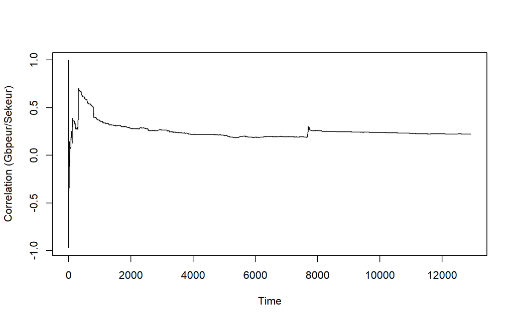

```r
#Compute average between the highest & lowest prices
gbpeurAverage <- (Dataset_TD5$GbpeurHIGH + Dataset_TD5$GbpeurLOW) / 2
cadeurAverage <- (Dataset_TD5$CadeurHIGH + Dataset_TD5$SekeurLOW) / 2
sekeurAverage <- (Dataset_TD5$SekeurHIGH + Dataset_TD5$SekeurLOW) / 2

# Transform the average prices into returns on the smallest time step
gbpeurReturns <- diff(gbpeurAverage)
cadeurReturns <- diff(cadeurAverage)
sekeurReturns <- diff(sekeurAverage)


# Initialize the wavelet coefficient matrices
gbpeurCoeffs <- matrix(nrow = length(gbpeurReturns), ncol = 1)
cadeurCoeffs <- matrix(nrow = length(cadeurReturns), ncol = 1)
sekeurCoeffs <- matrix(nrow = length(sekeurReturns), ncol = 1)

# Initial wavelet coefficient for each FX rate for the first return
sekeurCoeffs[1,1] <- sekeurReturns[1]
cadeurCoeffs[1,1] <- cadeurReturns[1]
gbpeurCoeffs[1,1] <- gbpeurReturns[1]


# Perform the Haar wavelet
for (i in 2:length(gbpeurReturns))
{
  gbpeurCoeffs[i,1] <- (gbpeurReturns[i] + gbpeurReturns[i-1]) / sqrt(2)
}
for (i in 2:length(sekeurReturns))
{
  sekeurCoeffs[i,1] <- (sekeurReturns[i] + sekeurReturns[i-1]) / sqrt(2)
}
for (i in 2:length(cadeurReturns))
{
  cadeurCoeffs[i,1] <- (cadeurReturns[i] + cadeurReturns[i-1]) / sqrt(2)
}

# Calculate the correlation between the two time series for each time period considered
vectCorrGbpeurSekeur <- rep(0, length(gbpeurCoeffs[, 1]))
for (i in 1:length(gbpeurCoeffs[ , 1])) {
  vectCorrGbpeurSekeur[i] <- cor(gbpeurCoeffs[1:i , 1], sekeurCoeffs[1:i, 1])
}

vectCorrSekeurCadeur <- rep(0, length(gbpeurCoeffs[, 1]))
for (i in 1:length(gbpeurCoeffs[ , 1])) {
  vectCorrSekeurCadeur[i] <- cor(sekeurCoeffs[1:i , 1], cadeurCoeffs[1:i, 1])
}

vectCorrGbpeurCadeur <- rep(0, length(gbpeurCoeffs[, 1]))
for (i in 1:length(gbpeurCoeffs[ , 1])) {
  vectCorrGbpeurCadeur[i] <- cor(gbpeurCoeffs[1:i , 1], cadeurCoeffs[1:i, 1])
}


# Plot the correlation versus time
plot( vectCorrGbpeurSekeur, type = "l", xlab = "Time", ylab = "Correlation (Gbpeur/Sekeur)" )
```

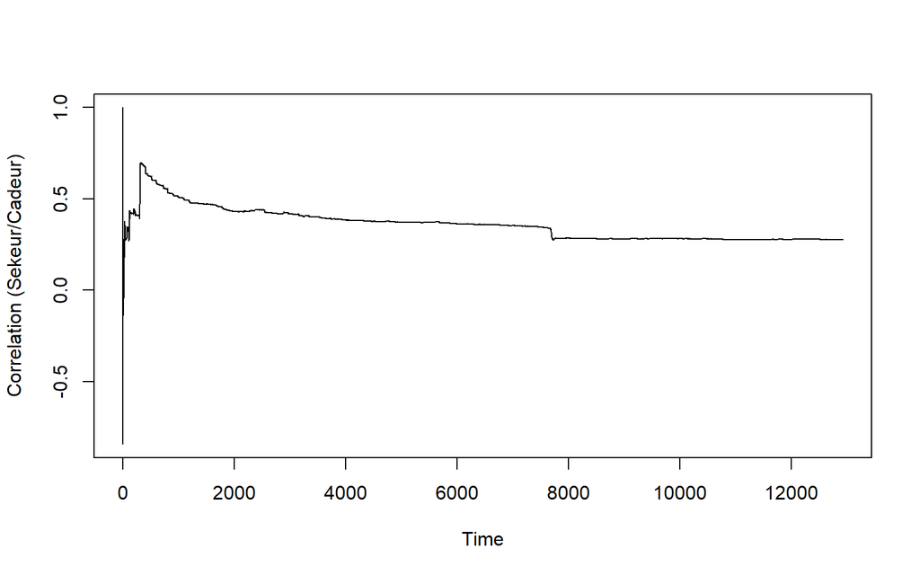

```r
plot( vectCorrSekeurCadeur, type = "l", xlab = "Time", ylab = "Correlation (Sekeur/Cadeur)" )
```

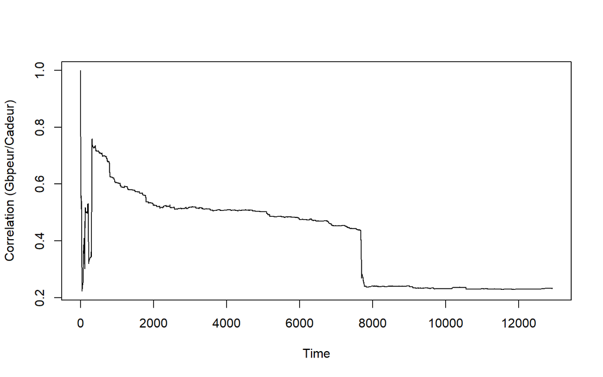

```r
plot( vectCorrGbpeurCadeur, type = "l", xlab = "Time", ylab = "Correlation (Gbpeur/Cadeur)" )
```

The **Epps** effect refers to the observation that the correlations between financial time series tend to **decrease** as the time horizon increases. So fx rate **are increasingly uncorrelated** as the time horizon increases. This could be due to the fact that different instruments are influenced by different underlying factors and drivers, and these influences may become more distinct over longer time horizons.

## b) Hurst exponent

> Calculate the Hurst exponent of GBPEUR, SEKEUR, and CADEUR. Determine their annualized volatility using the daily volatility and Hurst exponents.

**Data processing**

```r
df2 <- transform(df2 , X.1 = as.numeric(X.1))
df2 <- transform(df2 , X.2 = as.numeric(X.2))
df2 <- transform(df2 , X.5 = as.numeric(X.5))
df2 <- transform(df2 , X.6 = as.numeric(X.6))
df2 <- transform(df2 , X.9 = as.numeric(X.9))
df2 <- transform(df2 , X.10 = as.numeric(X.10))
df2[is.na(df2)] <- 0
str(df2)
```

```
## 'data.frame':    12931 obs. of  11 variables:
##  $ X   : chr  "GBPEUR Curncy" "Date" "3/7/2016 9:00" "3/7/2016 9:15" ...
##  $ X.1 : num  0 0 1.29 1.29 1.29 ...
##  $ X.2 : num  0 0 1.29 1.29 1.29 ...
##  $ X.3 : num  0 0 0 0 0 0 0 0 0 0 ...
##  $ X.4 : chr  "SEKEUR Curncy" "Date" "3/7/2016 9:00" "3/7/2016 9:15" ...
##  $ X.5 : num  0 0 0.107 0.107 0.107 ...
##  $ X.6 : num  0 0 0.107 0.107 0.107 ...
##  $ X.7 : num  0 0 0 0 0 0 0 0 0 0 ...
##  $ X.8 : chr  "CADEUR Curncy" "Date" "3/7/2016 9:00" "3/7/2016 9:15" ...
##  $ X.9 : num  0 0 0.684 0.685 0.684 ...
##  $ X.10: num  0 0 0.683 0.684 0.684 ...
```

```r
X <- c()
X1 <- c()
X2 <- c()
X <- (df2$X.1 + df2$X.2) / 2
X1 <- (df2$X.5 + df2$X.6) / 2
X2 <- (df2$X.9 + df2$X.10) / 2

df3 <- data.frame(X,X1,X2)
str(df3)
```

```
## 'data.frame':    12931 obs. of  3 variables:
##  $ X : num  0 0 1.29 1.29 1.29 ...
##  $ X1: num  0 0 0.107 0.107 0.107 ...
##  $ X2: num  0 0 0.684 0.684 0.684 ...
```

**Function which calculation M2**

```r
# N the step here every 15 minutes so it's 1
T = 12931
M2 = 0
M22 = 0
M23 = 0
for (i in 4:T)
{
  M2 = M2 + abs(X[i] - X[i-1])^2
  M22 = M22 + abs(X1[i] - X1[i-1])^2
  M23 = M23 + abs(X2[i] - X2[i-1])^2
}
M2 <- M2/T
M22 <- M22/T
M23 <- M23/T
M2
```

```
## [1] 6.01138e-07
```

```r
M22
```

```
## [1] 1.220952e-09
```

```r
M23
```

```
## [1] 1.209645e-07
```

**Function which calculation M2Prime**

```r
M2Prime = 0
M22Prime = 0
M23Prime = 0
T2 <- T/2
for (i in 4:T2)
{
   M2Prime = M2Prime + abs(X[2*i] - X[2*(i-1)])^2
   M22Prime = M22Prime + abs(X1[2*i] - X1[2*(i-1)])^2
   M23Prime = M23Prime + abs(X2[2*i] - X2[2*(i-1)])^2
}
M2Prime <- (2*M2Prime)/T
M22Prime <- (2*M22Prime)/T
M23Prime <- (2*M23Prime)/T
M2Prime
```

```
## [1] 1.558841e-06
```

```r
M22Prime
```

```
## [1] 3.132472e-09
```

```r
M23Prime
```

```
## [1] 3.104454e-07
```

Now we can calculate the **Hurst exponents** for the 3 pairs **GBPEUR, SEKEUR, and CADEUR**

```r
H1 <- (1/2) * log2(M2Prime/M2)
H2 <- (1/2) * log2(M22Prime/M22)
H3 <- (1/2) * log2(M23Prime/M23)

print(paste("Hurst exponents for GBPEUR:", H1))
```

```
## [1] "Hurst exponents for GBPEUR: 0.687352945229743"
```

```r
print(paste("Hurst exponents for SEKEUR:", H2))
```

```
## [1] "Hurst exponents for SEKEUR: 0.679647889032546"
```

```r
print(paste("Hurst exponents for CADEUR:", H3))
```

```
## [1] "Hurst exponents for CADEUR: 0.679877761569533"
```

Calcul **Volatility**

```r
# Volatility 15 min
V1 <- sd(X)
V2 <- sd(X1)
V3 <- sd(X2)

print(paste("Volatility at 15 min for GBPEUR:", V1))
```

```
## [1] "Volatility at 15 min for GBPEUR: 0.051462127537644"
```

```r
print(paste("Volatility at 15 min for SEKEUR:", V2))
```

```
## [1] "Volatility at 15 min for SEKEUR: 0.00190268796847517"
```

```r
print(paste("Volatility at 15 min for CADEUR:", V3))
```

```
## [1] "Volatility at 15 min for CADEUR: 0.0113553034094345"
```

```r
# Volatility 1 hour
V1H <- V1 * 4^H1
V2H <- V2 * 4^H2
V3H <- V3 * 4^H3

print(paste("Volatility at 1 hour for GBPEUR:", V1H))
```

```
## [1] "Volatility at 1 hour for GBPEUR: 0.133449037260692"
```

```r
print(paste("Volatility at 1 hour for SEKEUR:", V2H))
```

```
## [1] "Volatility at 1 hour for SEKEUR: 0.00488153462498248"
```

```r
print(paste("Volatility at 1 hour for CADEUR:", V3H))
```

```
## [1] "Volatility at 1 hour for CADEUR: 0.0291424420892775"
```

```r
# Volatility 1 day
V1J <- V1H * 24^H1
V2J <- V2H * 24^H2
V3J <- V3H * 24^H3

print(paste("Volatility at 1 day for GBPEUR:", V1J))
```

```
## [1] "Volatility at 1 day for GBPEUR: 1.18578979114456"
```

```r
print(paste("Volatility at 1 day for SEKEUR:", V2J))
```

```
## [1] "Volatility at 1 day for SEKEUR: 0.0423266630568395"
```

```r
print(paste("Volatility at 1 day for CADEUR:", V3J))
```

```
## [1] "Volatility at 1 day for CADEUR: 0.252872074629809"
```

```r
# Volatility 1 year
V1A <- V1J * 252^H1
V2A <- V2J * 252^H2
V3A <- V3J * 252^H3

print(paste("Volatility at 1 year for GBPEUR:", V1A))
```

```
## [1] "Volatility at 1 year for GBPEUR: 53.0417008005218"
```

```r
print(paste("Volatility at 1 year for SEKEUR:", V2A))
```

```
## [1] "Volatility at 1 year for SEKEUR: 1.81434903991345"
```

```r
print(paste("Volatility at 1 year for CADEUR:", V3A))
```

```
## [1] "Volatility at 1 year for CADEUR: 10.8532472266243"
```

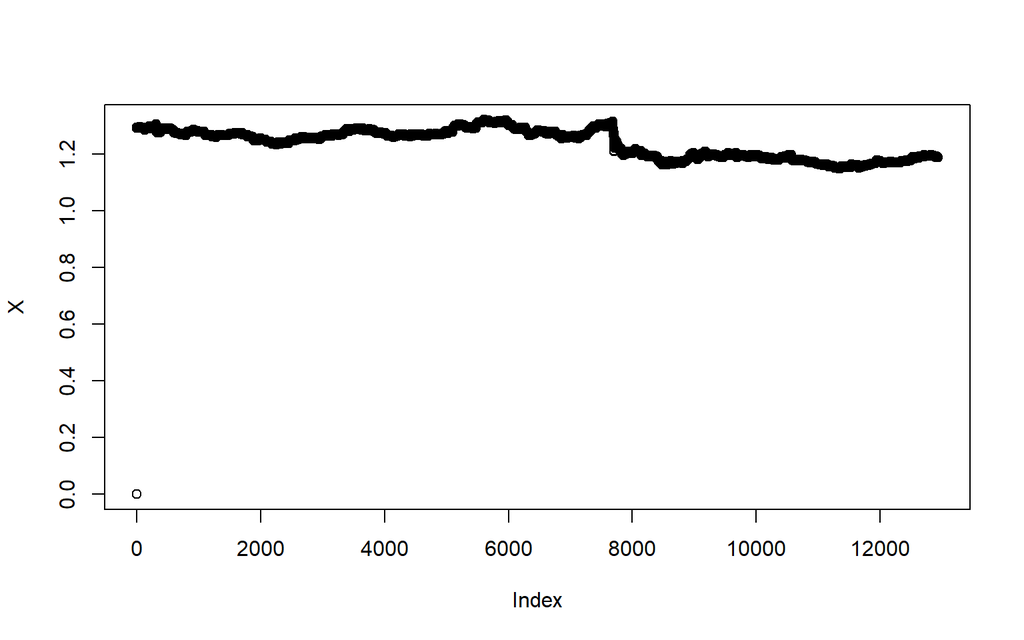

```r
plot(X)
```

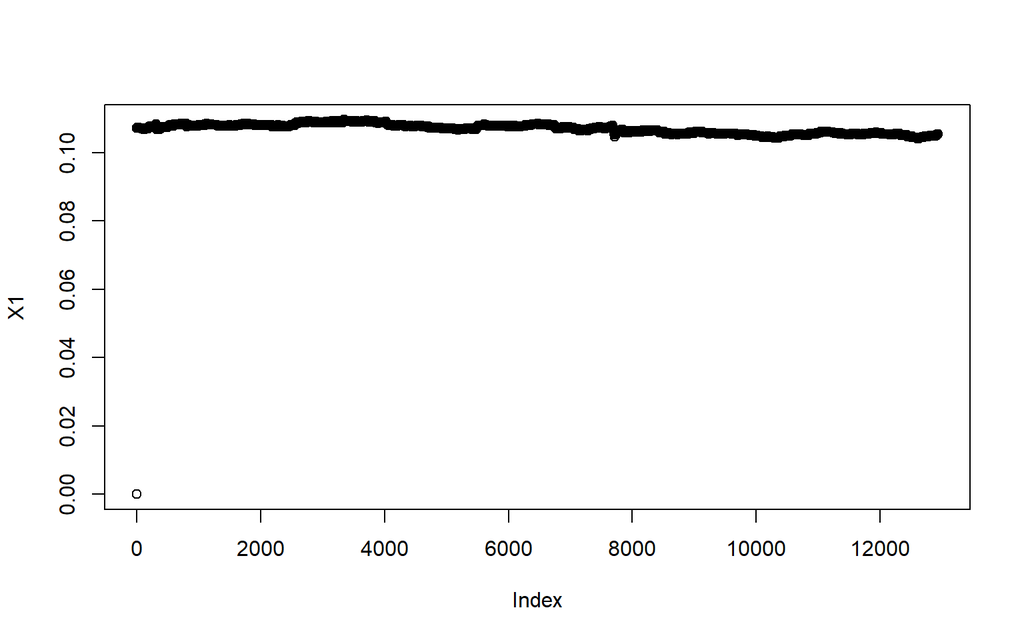

```r
plot(X1)
```

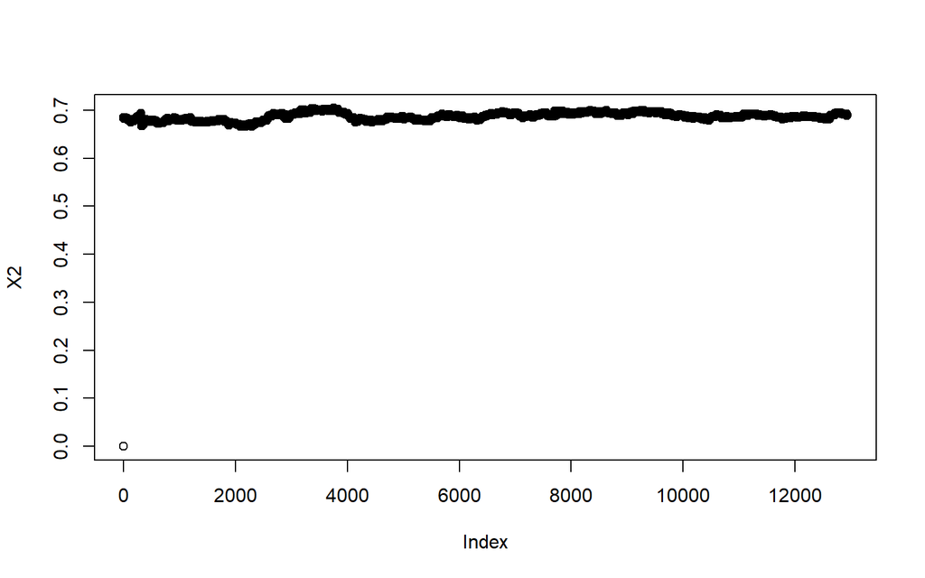

```r
plot(X2)
```